# S7e: terzo meccanismo generatore (copula gaussiana, correlazione solo seriale)

Roadmap Morris 2019, ramo morris-v4

Data di Pubblicazione

24 ottobre 2026

## In breve: le conclusioni del paper reggono con dati che non vengono dal modello di nessun metodo?

**A cosa serviva.** I tre modi in cui lo studio genera i dati hanno tutti una componente che resta costante per ogni soggetto: è proprio ciò che assumono il modello misto (qui il modello logistico a effetti casuali per soggetto), il modello marginalizzato multilivello e la GEE con correlazione exchangeable. Abbiamo aggiunto un quarto modo in cui la correlazione fra visite dello stesso soggetto si spegne con la distanza, senza parte costante, mentre l’effetto del trattamento nel tempo sulla scala della popolazione è esattamente quello voluto. Abbiamo simulato tutte le 480 situazioni della griglia principale, 1.000 simulazioni per scenario con e senza effetto, con tutte le strategie del paper e quelle aggiunte nel passaggio precedente.

**Cosa abbiamo trovato.**

1. **La raccomandazione della Figura 1 non cambia: resta la GEE con correlazione AR(1), la correzione di Fay e Graubard e la t, con il modello marginalizzato come alternativa equivalente.**
   - Con i dati nuovi nessuna delle due è mai fuori taratura verso l’alto: in media 4,6 e 5,1 falsi positivi su 100.
   - Applicata a tutte le 2.376 situazioni dei quattro modi di generare i dati, la regola sceglie la stessa GEE: risponde nel 92,1% dei dataset, il modello marginalizzato nel 90,9%.
   - Un’avvertenza: la correlazione AR(1) somiglia alla dipendenza dei dati nuovi, che le sono quindi un po’ favorevoli; la regola però la sceglieva già con i tre modi dello studio.
   - Con questa dipendenza tutte le strategie trovano un effetto vero un po’ meno spesso: 17-19 tentativi su 100 invece di 20-22.
2. **Il modello marginalizzato stima bene l’effetto anche quando la sua descrizione della dipendenza è sbagliata, purché si usi il controllo di convergenza.**
   - La distorsione è trascurabile e l’intervallo al 95% contiene il valore vero nel 94% dei casi (95% con la t).
   - Rispetto agli altri modi ha meno di un falso positivo su 100 in più: sotto la soglia di importanza.
   - Senza il controllo di convergenza è fuori taratura verso l’alto in 59 situazioni.
3. **Il modello misto peggiora molto: 10 falsi positivi su 100 in media, 3 in più che con gli altri modi, ed è fuori taratura verso l’alto in 219 situazioni su 480 (con gli altri modi da 38 a 100).**
   - Quando ha solo l’intercetta casuale, il suo errore standard ignora la correlazione più forte fra visite vicine ed è circa fra due terzi e quattro quinti di quello giusto; con molti soggetti si arriva a quasi 20 falsi positivi su 100. La stima invece è centrata.
   - Con le pendenze casuali e 8-10 visite torna vicino a 5 su 100.
4. **Il test a inversione di segno resta tarato: 5,2 falsi positivi su 100 in media, mai fuori taratura verso l’alto, e risponde in almeno 98 dataset su 100 in ogni situazione.**
5. **La GEE usata finora nel paper, con correlazione exchangeable e Fay e Graubard, esce dalla taratura in 5 situazioni, tutte con 4 visite e 10-25 soggetti, con circa 10 falsi positivi su 100.** Con gli altri modi non succedeva mai.

**Cosa devi decidere.**

1. **Come entra il nuovo modo di generare i dati nel paper? Consiglio di presentarlo nel testo principale come quarto meccanismo, con la regola della Figura 1 calcolata su tutti e quattro, una frase sul modello misto e i dettagli nel supplemento.**
   - Risponde direttamente al limite “ogni meccanismo è il modello di un metodo”, e porta un risultato nuovo sul modello misto.
   - Alternativa: solo nel supplemento, citato in una frase come verifica di robustezza. Il testo principale cambia meno, ma il limite resta scritto lì e il risultato sul modello misto passa in secondo piano.
   - Alternativa: in tutte le tabelle e figure principali accanto agli altri tre. È più completo, ma appesantisce un testo già vicino al limite di parole.

**Comunque:**

- quando riscriveremo il paper, la frase sui meccanismi come modelli di casa, quelle sul modello misto e sulla GEE exchangeable, e la regola della Figura 1 useranno questi numeri;
- il controllo di completezza fallito alla lettera (344 dataset su 960.000 senza la riga dell’effetto per il modello marginalizzato o per il modello misto, tutti in disegni in cui l’effetto non è stimabile e che sono comunque esclusi) è spiegato nel report e non tocca nessun risultato.

Appena decidi questo punto, lo step è chiuso.

Il PI ha deciso il punto il 2026-10-24, con la raccomandazione: step chiuso.

**Sui tempi di calcolo.** Il run è durato 26,4 ore sul server, con 20-25 processi regolati dalla temperatura. Prima del run l’agente aveva stimato circa 23 ore con 24 processi, dai tempi di una prova su 600 simulazioni e da quelli del run precedente per la GEE; il costo reale delle situazioni più grandi dello scenario con la dose è stato circa 1,4 volte quello stimato.

# Dubbi rinviati

Nessuno. Il testo da scrivere passa all’Aggiornamento del manoscritto con le analisi aggiunte (S7f), dubbio ricevuto 5.

# Cancelli e previsioni

Attese pre-registrate (commit `9e4c8ae`, prima di ogni analisi sui dati del nuovo meccanismo):

[output not shown]

Valori in `tables/V4_S7e_predictions.csv` (intervallo = percentili 2,5 e 97,5 del bootstrap per blocchi; per i conteggi il valore intero).

| codice | atteso | intervallo | osservato (intervallo per blocchi) | esito |
| --- | --- | --- | --- | --- |
| PF1 | 0 | 0 | 0 | confermata |
| PF2 | 0 | da -1 a +1 | -0,04 (-0,11 a +0,03) | confermata |
| PF3 | 0 | 0 | 0 | confermata |
| PF4 | 0 | 0 | 0 | confermata |
| PF5 | 0 | da -1 a +1 | +0,23 (+0,16 a +0,30) | confermata |
| PF6 | +0,5 | da -1 a +1 | +0,71 (+0,64 a +0,79) | confermata |
| PF7 | 0 | da -0,46 a +0,46 | 0,027 (0,023 a 0,030); nessun punto fuori | confermata |
| PF8 | 94% | da 92,5% a 97,5% | 93,8% (93,7 a 93,9) | confermata |
| PF9 | +1,5 | da +1 a +10 | +3,2 (+3,0 a +3,5), 418 punti | confermata |
| PF10 | GEE AR(1) con Fay e Graubard e t | stessa | GEE AR(1) con Fay e Graubard e t (92,1% di risposte; modello marginalizzato con controllo 90,9%) | confermata |
| PF11 | 0 | da -2,5 a +2,5 | -0,58 (-0,66 a -0,50) | confermata |

PF5, PF6 e PF11 sono differenze che si distinguono dal caso ma restano dentro la soglia di importanza: si scrivono come trascurabili. PF9 su 418 punti perche’ in 62 punti il modello misto con pendenze casuali non ha replicati usabili in almeno un meccanismo (serie di 2-3 visite, come in GLMM con pendenze casuali non stimabile nelle serie piu’ corte (D-20)); limitandosi ai 414 punti con almeno 20 replicati usabili in tutti i meccanismi lo scarto resta +3,2 punti.

Esito:

Run: `R/s7e/s7e_run.R`, 9.600 chunk (960.000 dataset), 20-25 processi regolati dalla temperatura (guardia `R/s7e/s7e_thermal_guard.sh`), 26,4 ore, 0 chunk falliti; pre-registrazione `9e4c8ae`, script di aggregazione committato prima del run (`8fbe6de`; dopo, due correzioni dello strumento descritte sotto). Aggregazione `R/s7e/s7e_agg.R`; riassunti e figure `R/s7e/s7e_summary.R`; controlli dopo il run `R/s7e/s7e_gate_reprod.R`, `R/s7e/s7e_explain.R`, `R/s7e/s7e_glmm_pseudotrue.R`, `R/s7e/s7e_glmm_se_ratio.R`, `R/s7e/s7e_glmm_singular.R`, `R/s7e/s7e_glmm_by_scen_T.R`. Tabelle `tables/V4_S7e_*.csv`.

**Correzioni dello strumento di aggregazione** (provate sui primi chunk, prima di leggere qualsiasi risultato aggregato): (1) il controllo di completezza contava come mancante una tecnica senza riga `time:trt`; si riportano ora i dataset mancanti e, fra questi, quelli con disegno stimabile; (2) i quantili del bootstrap ignorano i punti senza replicati usabili in una replica bootstrap (`na.rm`).

## Cancelli

[output not shown]

## Previsioni

Valori in `tables/V4_S7e_predictions.csv` (intervallo = percentili 2,5 e 97,5 del bootstrap per blocchi; per i conteggi il valore intero).

| codice | atteso | intervallo | osservato (intervallo per blocchi) | esito |
| --- | --- | --- | --- | --- |
| PF1 | 0 | 0 | 0 | confermata |
| PF2 | 0 | da -1 a +1 | -0,04 (-0,11 a +0,03) | confermata |
| PF3 | 0 | 0 | 0 | confermata |
| PF4 | 0 | 0 | 0 | confermata |
| PF5 | 0 | da -1 a +1 | +0,23 (+0,16 a +0,30) | confermata |
| PF6 | +0,5 | da -1 a +1 | +0,71 (+0,64 a +0,79) | confermata |
| PF7 | 0 | da -0,46 a +0,46 | 0,027 (0,023 a 0,030); nessun punto fuori | confermata |
| PF8 | 94% | da 92,5% a 97,5% | 93,8% (93,7 a 93,9) | confermata |
| PF9 | +1,5 | da +1 a +10 | +3,2 (+3,0 a +3,5), 418 punti | confermata |
| PF10 | GEE AR(1) con Fay e Graubard e t | stessa | GEE AR(1) con Fay e Graubard e t (92,1% di risposte; modello marginalizzato con controllo 90,9%) | confermata |
| PF11 | 0 | da -2,5 a +2,5 | -0,58 (-0,66 a -0,50) | confermata |

PF5, PF6 e PF11 sono differenze che si distinguono dal caso ma restano dentro la soglia di importanza: si scrivono come trascurabili. PF9 su 418 punti perche’ in 62 punti il modello misto con pendenze casuali non ha replicati usabili in almeno un meccanismo (serie di 2-3 visite, come in GLMM con pendenze casuali non stimabile nelle serie piu’ corte (D-20)); limitandosi ai 414 punti con almeno 20 replicati usabili in tutti i meccanismi lo scarto resta +3,2 punti.

## Osservazioni non previste, chiuse

1. **Modello misto molto liberale con la sola intercetta casuale.** Negli scenari M1 e M2 l’errore di I tipo del Wald cresce con N fino a 19,5% (con N >= 85 fra 8,9% e 19,5%). Non e’ un valore limite diverso da zero: su 20.000 soggetti sotto H0 il modello misto converge a 0,005 (SE 0,005) con 10 visite e 0,036 (SE 0,024) con 4 (`tables/V4_S7e_glmm_pseudotrue.csv`), e le stime sono centrate (in M1 e M2, con N >= 85, distorsione / SE empirico sotto 0,04 in media per scenario e T e al massimo 0,09 per punto). E’ l’errore standard: con N >= 85 l’errore standard del modello e’ fra 0,64 e 0,81 volte la dispersione delle stime, che con la normale implica fra 11% e 21% di rifiuti, come osservato (`tables/V4_S7e_glmm_se_ratio.csv`). L’intercetta casuale assume la stessa correlazione fra tutte le visite e ignora quella, piu’ forte, fra visite vicine, che pesa proprio sull’effetto che varia nel soggetto. Con le pendenze casuali (M3-M5) e 8-10 visite il rapporto e’ circa 1 e l’errore torna fra 5,3% e 6,2%; con 3-6 visite resta fra 8% e 16% (`tables/V4_S7e_glmm_by_scen_T.csv`), lo stesso andamento degli altri meccanismi ma piu’ marcato (negli altri: 4-15%). Spiegato.
2. **GEE exchangeable con Fay e Graubard chiaramente sopra 7,5% in 5 punti** (0 negli altri meccanismi): M1 con N 10-25 e M3 con N 15, tutti con T = 4, tassi fra 9,6% e 10,4% (`R/s7e/s7e_explain.R`). Negli stessi punti la GEE AR(1) con Fay e Graubard e’ fra 7,0% e 8,3% (mai chiaramente sopra) e la correlazione indipendente fra 7,4% e 9,7% (chiaramente sopra in 1 punto della griglia). In media sui punti con T = 4 la exchangeable e’ a 6,1% contro 5,4% dell’AR(1). Con dipendenza solo seriale la correlazione exchangeable e’ la piu’ lontana dal vero; non tocca la Figura 1, che usa la AR(1). Spiegato; la frase del paper sulla GEE exchangeable va aggiornata.
3. **La correlazione AR(1) e’ vicina alla dipendenza di questo meccanismo.** Era stato detto al PI prima della scelta. La regola della Figura 1 sceglieva la GEE AR(1) gia’ sui tre meccanismi dello studio (92,2% di risposte), quindi la conclusione non poggia sul nuovo meccanismo. Spiegato.
4. **Meno potenza per tutte le strategie marginali** (17-19 tentativi su 100 contro 20-22 negli altri meccanismi): con correlazione seriale l’informazione sulla pendenza nel soggetto e’ minore. Il modello misto resta a 23-24 perche’ liberale. Atteso, non tocca conclusioni.
5. **Modello marginalizzato senza il controllo di convergenza**: chiaramente sopra 7,5% in 59 punti (con il controllo 0); conferma la scelta di Il modello marginalizzato si analizza con un controllo di convergenza negli scenari con pendenza della deviazione standard latente (D-32).

Valori calcolati (`tables/V4_S7e_predictions.csv`):

| code | obs | lo | hi | a | b | verdict | extra |
| --- | --- | --- | --- | --- | --- | --- | --- |
| PF1 | 0 | 0 | 0 | 0 | 0 | confermata |  |
| PF2 | -0.04262 | -0.1141 | 0.02758 | -1 | 1 | confermata |  |
| PF3 | 0 | 0 | 0 | 0 | 0 | confermata |  |
| PF4 | 0 | 0 | 0 | 0 | 0 | confermata |  |
| PF5 | 0.2307 | 0.1582 | 0.2983 | -1 | 1 | confermata |  |
| PF6 | 0.7141 | 0.6424 | 0.7855 | -1 | 1 | confermata |  |
| PF7 | 0.0268 | 0.02315 | 0.03046 | -0.46 | 0.46 | confermata | H1 points with bias/empSE +/- 2 MCSE wholly outside +/- 0.46: 0 |
| PF8 | 93.78 | 93.71 | 93.85 | 92.5 | 97.5 | confermata |  |
| PF9 | 3.199 | 3.017 | 3.459 | 1 | 10 | confermata |  |
| PF10 | 1 | 1 | 1 | 1 | 1 | confermata | chosen: gee_ar1_fg |
| PF11 | -0.5766 | -0.6623 | -0.4968 | -2.5 | 2.5 | confermata |  |

Medie sui 480 punti con bootstrap per blocchi (`tables/V4_S7e_boot_means.csv`):

| q | est | lo | hi | sd | n_pts |
| --- | --- | --- | --- | --- | --- |
| flip rate H0, copula | 5.236 | 5.173 | 5.299 | 0.03122 | 480 |
| flip rate H0, copula - study mechanisms | -0.04262 | -0.1141 | 0.02758 | 0.0361 | 480 |
| GEE AR(1) FG t rate H0, copula | 4.553 | 4.488 | 4.613 | 0.032 | 480 |
| GEE AR(1) FG t rate H0, copula - study mechanisms | 0.2307 | 0.1582 | 0.2983 | 0.03666 | 480 |
| MMM cc t rate H0, copula | 5.137 | 5.074 | 5.202 | 0.0333 | 480 |
| MMM cc t rate H0, copula - study mechanisms | 0.7141 | 0.6424 | 0.7855 | 0.03725 | 480 |
| GLMM Wald t rate H0, copula | 10.21 | 9.729 | 10.35 | 0.1635 | 421 |
| GLMM Wald t rate H0, copula - study mechanisms | 3.199 | 3.017 | 3.459 | 0.112 | 418 |
| MMM cc usable H0, copula | 90.58 | 90.5 | 90.65 | 0.03985 | 480 |
| MMM cc usable H0, copula - study mechanisms | -0.5766 | -0.6623 | -0.4968 | 0.0429 | 480 |
| MMM cc bias/empSE H1, copula | 0.0268 | 0.02315 | 0.03046 | 0.001882 | 480 |
| MMM cc coverage (normal) H1, copula | 93.78 | 93.71 | 93.85 | 0.03785 | 480 |

# Scelta del meccanismo e controlli prima del run

Nessun metodo e’ stato applicato ai dati del nuovo meccanismo prima di questa scelta, salvo una sonda dei tempi (`R/s7e/s7e_timing.R`, 8 replicati in 7 celle, H0) di cui non si e’ calcolata ne’ letta alcuna misura di prestazione.

**Profilo di dipendenza dei meccanismi** (`R/s7e/s7e_profiles.R`; un dataset di 20.000 soggetti per meccanismo, M1, H0, 10 visite, seme 20261023; correlazione di Pearson dei residui standardizzati fra visite dello stesso soggetto; `tables/V4_S7e_dependence_summary.csv`):

| meccanismo | visite consecutive | distanza 3 | distanza 9 | media su 10 visite |
| --- | --- | --- | --- | --- |
| GenBinaryY | 0,312 | 0,163 | 0,136 | 0,194 |
| GLMM-native | 0,132 | 0,133 | 0,129 | 0,134 |
| GLMM-AR1 | 0,150 | 0,135 | 0,087 | 0,131 |
| copula, solo seriale, rho 0,6 (scelta) | 0,361 | 0,111 | -0,002 | 0,141 |

I tre meccanismi dello studio hanno una componente costante per soggetto; la copula scelta no. Scelta del PI: Il quarto meccanismo e’ una copula gaussiana con margini logistici e correlazione solo seriale (rho = 0,6) (D-53). Organizzazione tecnica: Organizzazione tecnica del run del quarto meccanismo: semi dello studio, correzioni da fewclust, geesmv sui primi 50 replicati (D-54), che sostituisce la riga del piano sui semi.

- **Meccanismo** (etichetta `Copula-AR1`): P(Y_ij = 1) = expit(X_ij’ beta) con il modello medio e i coefficienti marginali dello studio (M1: -2, 0,1, 0,2, 0,2; M2: con age 0,01; M3 come M1; M4: -2, 0,2, 0,2, 0,05; M5: con dose 0,05); sotto H0 cambia solo `time:trt`, che vale 0. Y_ij = 1{Z_ij <= qnorm(expit(X_ij’ beta))}, Z_i ~ N(0, R), R[j,k] = 0,6^|t_j - t_k|[^ep1991][^song2009][^mv2012]. Valore vero marginale = beta esattamente, su ogni disegno realizzato. Il modello misto non ha un valore vero nel generatore: distorsione, copertura e errore quadratico medio del modello misto non sono definiti, come per GenBinaryY (Nessun valore vero condizionale per GenBinaryY (D-18)); il suo errore di I tipo si riporta.
- **Griglia**: M1-M5 x N in {10, 15, 20, 25, 35, …, 145} x T in {2, 3, 4, 6, 8, 10} = 480 punti, H0 e H1, 1.000 replicati per braccio, 9.600 chunk di 100 replicati, 960.000 dataset.
- **Strategie per replicato** (`R/s7e/s7e_common.R`): modello marginalizzato (studio), modello marginalizzato con controllo di convergenza in M3-M5, GEE exchangeable di geepack, modello misto con Wald (opzioni di default) e riscalamento shrinkage, modello misto con LRT (bobyqa, pendenze casuali del Wald); GEE con correlazione exchangeable, indipendente e AR(1), ciascuna con sandwich non corretto e con Mancl e DeRouen, Kauermann e Carroll e Fay e Graubard di fewclust, CR2 di clubSandwich su exchangeable e indipendente, geesmv sui replicati 1-50; test a inversione di segno principale e con filtro.
- **Misure**: come nel protocollo (sez. 5), usabilita’ U0, denominatore senza i disegni non stimabili, riferimento t a N - p per la regola della Figura 1 e normale per le tabelle, bandiere “chiaramente sopra 7,5%” = tasso - 2 MCSE > 7,5 con almeno 20 replicati usabili.
- **Confronto con gli altri meccanismi**: per ogni punto, tasso della copula meno la media dei tassi dei tre meccanismi dello studio nello stesso punto (stessi disegni, stessi semi); intervallo dal bootstrap per blocchi di replicato con gli indici di `results_v4/S4/boot_idx.rds` (B = 2000, seed 20261015), gli stessi per i quattro meccanismi.
- **Regola della Figura 1** (La regola della Figura 1 si applica alle strategie con stima e intervallo: sceglie la GEE AR(1) con Fay e Graubard e la t; il test a inversione di segno e’ complementare (D-50)): sulle strategie con stima e intervallo, sui 480 punti della copula da soli e sui 2.376 punti (1.896 + 480) insieme.
- **Integrita’ e parita’** (parte di GF1): md5 dei 28.800 file di `results_full/` uguali alla lista di S7b (`results_v4/S7e/md5_results_full_before.txt`, 0 differenze); `R/testing/test_h0h1_parity.R` passa (griglia principale 15/15, M1c 3/3, controllo di Varianza della pendenza su dose allineata in M5 (D-02) 8/8).
- **GF2 passa** (`R/s7e/s7e_gates_pre.R`, `tables/V4_S7e_GF2.csv`): 1.000 replicati (5 scenari x 2 disegni x 100); disegno identico fra H0 e H1 e stessi numeri normali in tutti; disegno identico a GLMM-native in tutti e a GLMM-AR1 in tutti quelli in cui GLMM-AR1 genera (10 errori di generazione di GLMM-AR1, tutti in disegni non stimabili, a N = 10 e T = 2).
- **GF3 passa** (`tables/V4_S7e_GF3.csv`): in M1, M3 e M4 la massima abs(z) e’ 2,7 su 60 celle marginali e 270 celle di coppia; in M2 e M5 la GEE di indipendenza recupera ogni coefficiente entro 1,5 errori standard robusti.
- **Prova su 6 chunk** (`R/s7e/s7e_run.R 6`, 600 replicati, 0 chunk falliti): secondi per replicato da 1,4 (N = 10, T = 2) a 12,6 (M5, N = 145, T = 10), di cui 9,8 per le analisi dello studio (soprattutto il modello misto con tre effetti casuali e il suo LRT) e 1,8 per il controllo di convergenza del modello marginalizzato. Stima del run intero, fatta dall’agente da questi tempi e da quelli del run precedente per la parte GEE: circa 550 ore di processore, cioe’ circa 23 ore con 24 processi. I 6 chunk restano come parte del run.

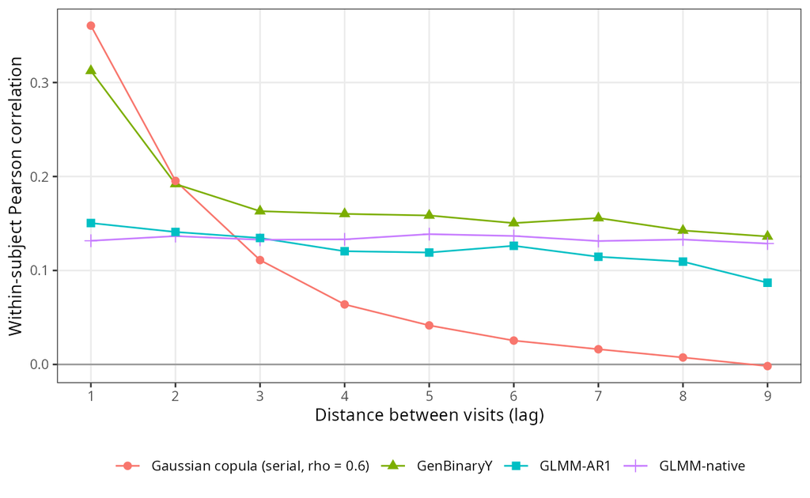

Correlazione di Pearson fra visite dello stesso soggetto per distanza, nei tre meccanismi dello studio e nella copula scelta (M1, H0, 10 visite, 20.000 soggetti).

Profili riassunti (`tables/V4_S7e_dependence_summary.csv`):

| mech | prev | lag1 | lag3 | lag9 | mean_T10 | mean_T4 |
| --- | --- | --- | --- | --- | --- | --- |
| GenBinaryY | 0.1923 | 0.3124 | 0.1631 | 0.1362 | 0.1941 | 0.2474 |
| GLMM-native | 0.1934 | 0.1316 | 0.1327 | 0.1286 | 0.1341 | 0.1334 |
| GLMM-AR1 | 0.1886 | 0.1505 | 0.1345 | 0.08695 | 0.131 | 0.1446 |
| copula floor=0.00 rho=0.5 | 0.1913 | 0.2862 | 0.0618 | -0.008897 | 0.09764 | 0.1974 |
| copula floor=0.00 rho=0.6 | 0.1913 | 0.3605 | 0.111 | -0.001751 | 0.1409 | 0.2639 |
| copula floor=0.00 rho=0.7 | 0.1913 | 0.4465 | 0.1829 | 0.01579 | 0.2012 | 0.3461 |
| copula floor=0.00 rho=0.8 | 0.1904 | 0.5437 | 0.2891 | 0.07048 | 0.2962 | 0.45 |
| copula floor=0.00 rho=0.9 | 0.1897 | 0.6781 | 0.4705 | 0.2093 | 0.4611 | 0.6031 |
| copula floor=0.15 rho=0.5 | 0.1918 | 0.3423 | 0.1327 | 0.06873 | 0.1649 | 0.2591 |
| copula floor=0.15 rho=0.6 | 0.1914 | 0.4121 | 0.1774 | 0.07079 | 0.2039 | 0.3205 |
| copula floor=0.15 rho=0.7 | 0.1909 | 0.4857 | 0.2421 | 0.08758 | 0.2603 | 0.3933 |
| copula floor=0.15 rho=0.8 | 0.19 | 0.5791 | 0.3467 | 0.1347 | 0.351 | 0.4931 |
| copula floor=0.15 rho=0.9 | 0.19 | 0.7059 | 0.5128 | 0.2707 | 0.5038 | 0.6364 |
| copula floor=0.30 rho=0.5 | 0.1914 | 0.4002 | 0.2091 | 0.1541 | 0.2392 | 0.324 |
| copula floor=0.30 rho=0.6 | 0.1911 | 0.4615 | 0.2494 | 0.1536 | 0.2749 | 0.3792 |
| copula floor=0.30 rho=0.7 | 0.1904 | 0.5314 | 0.3102 | 0.1728 | 0.3275 | 0.4483 |
| copula floor=0.30 rho=0.8 | 0.1899 | 0.6173 | 0.4064 | 0.2125 | 0.4106 | 0.5398 |
| copula floor=0.30 rho=0.9 | 0.19 | 0.7308 | 0.555 | 0.3303 | 0.5461 | 0.6676 |

# Risultati sul nuovo meccanismo

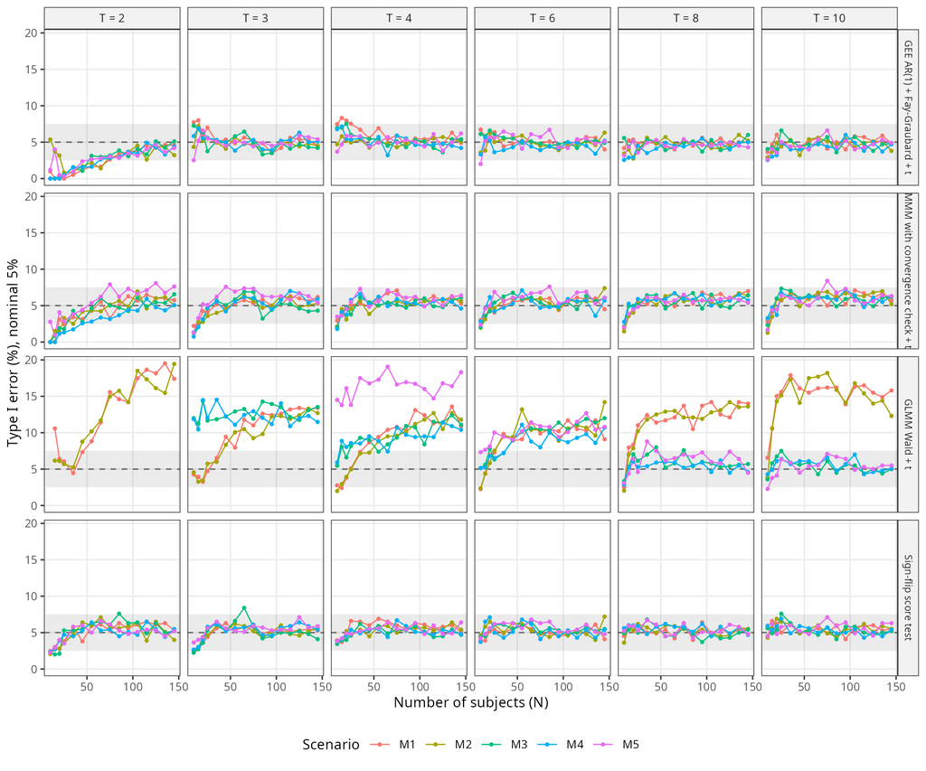

Errore di I tipo per punto di disegno nel nuovo meccanismo (riferimento t a N - p; fascia grigia 2,5-7,5%; punti con almeno 20 replicati usabili).

Cosa guardare: la GEE AR(1) con Fay e Graubard, il modello marginalizzato con controllo e il test a inversione di segno restano nella fascia; il modello misto ne esce negli scenari con la sola intercetta casuale (M1, M2) a ogni T e in M3-M5 con 3-6 visite.

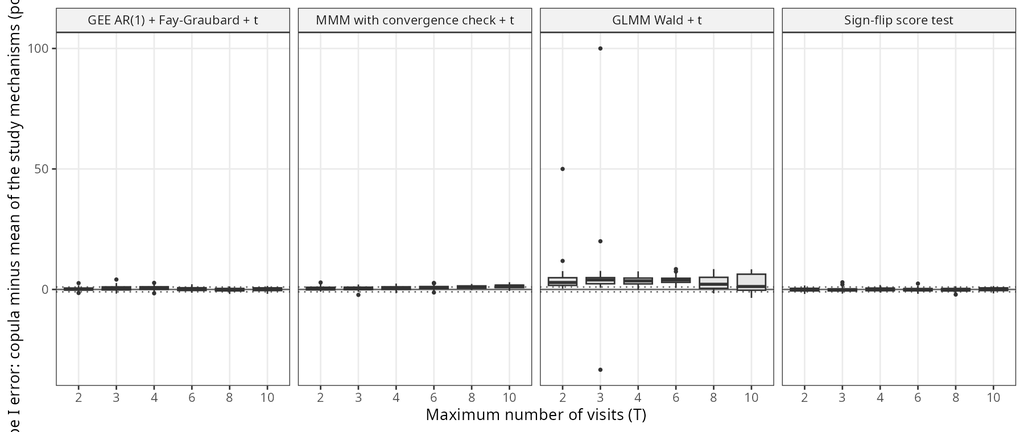

Errore di I tipo: nuovo meccanismo meno la media dei tre meccanismi dello studio nello stesso punto, per T (linee tratteggiate: +/- 1 punto).

Cosa guardare: le scatole delle tre strategie tarate stanno attorno a zero entro un punto; quella del modello misto sta sopra.

## Riassunto per strategia e meccanismo

Griglia principale (480 punti per meccanismo), riferimento t a N - p; `tables/V4_S7e_summary.csv`. Righe senza valore per i meccanismi dello studio: strategia non disponibile nelle tabelle salvate.

**mean_type1**

| label | AR1 | Copula-AR1 | GenBinaryY | native |
| --- | --- | --- | --- | --- |
| GEE AR(1) + Fay-Graubard + t | 4.235 | 4.553 | 4.496 | 4.234 |
| GEE AR(1), uncorrected sandwich + t | 6.559 | 7.002 | 6.934 | 6.515 |
| GEE exch. + Fay-Graubard + t | 4.467 | 4.984 | 4.927 | 4.424 |
| GEE exch. + Kauermann-Carroll + t | 5.377 | 6.046 | 5.965 | 5.306 |
| GEE exch. + Mancl-DeRouen + t | 4.666 | 5.248 | 5.167 | 4.597 |
| GEE exch., uncorrected sandwich + t | 6.71 | 7.502 | 7.409 | 6.647 |
| GEE indep. + Fay-Graubard + t | 4.246 | 4.694 | 4.57 | 4.203 |
| GLMM Wald + t | 6.196 | 10.21 | 8.019 | 5.653 |
| GLMM likelihood-ratio test | NA | 9.371 | NA | NA |
| MMM as in the study (no check) + t | NA | 6.35 | NA | NA |
| MMM with convergence check + t | 4.415 | 5.137 | 4.571 | 4.283 |
| Shrinkage GLM + t | 6.967 | 11.4 | 8.785 | 6.249 |
| Sign-flip score test | 5.244 | 5.236 | 5.3 | 5.293 |

**clearly_above**

| label | AR1 | Copula-AR1 | GenBinaryY | native |
| --- | --- | --- | --- | --- |
| GEE AR(1) + Fay-Graubard + t | 0 | 0 | 0 | 0 |
| GEE AR(1), uncorrected sandwich + t | 62 | 80 | 77 | 60 |
| GEE exch. + Fay-Graubard + t | 0 | 5 | 0 | 0 |
| GEE exch. + Kauermann-Carroll + t | 25 | 57 | 44 | 22 |
| GEE exch. + Mancl-DeRouen + t | 0 | 22 | 13 | 1 |
| GEE exch., uncorrected sandwich + t | 71 | 92 | 86 | 62 |
| GEE indep. + Fay-Graubard + t | 0 | 1 | 0 | 0 |
| GLMM Wald + t | 38 | 219 | 100 | 38 |
| GLMM likelihood-ratio test | NA | 189 | NA | NA |
| MMM as in the study (no check) + t | NA | 59 | NA | NA |
| MMM with convergence check + t | 0 | 0 | 0 | 0 |
| Shrinkage GLM + t | 56 | 240 | 119 | 56 |
| Sign-flip score test | 0 | 0 | 0 | 0 |

**mean_usable**

| label | AR1 | Copula-AR1 | GenBinaryY | native |
| --- | --- | --- | --- | --- |
| GEE AR(1) + Fay-Graubard + t | 92.4 | 91.64 | 91.78 | 92.69 |
| GEE AR(1), uncorrected sandwich + t | 94.03 | 93.63 | 93.71 | 94.25 |
| GEE exch. + Fay-Graubard + t | 92.44 | 91.75 | 91.91 | 92.73 |
| GEE exch. + Kauermann-Carroll + t | 92.29 | 91.49 | 91.7 | 92.6 |
| GEE exch. + Mancl-DeRouen + t | 92.33 | 91.66 | 91.82 | 92.63 |
| GEE exch., uncorrected sandwich + t | 94.07 | 93.75 | 93.86 | 94.28 |
| GEE indep. + Fay-Graubard + t | 92.54 | 91.96 | 92.11 | 92.82 |
| GLMM Wald + t | 81.17 | 79.18 | 79.87 | 81.46 |
| GLMM likelihood-ratio test | NA | 86.43 | NA | NA |
| MMM as in the study (no check) + t | NA | 89.56 | NA | NA |
| MMM with convergence check + t | 91.17 | 90.58 | 90.78 | 91.51 |
| Shrinkage GLM + t | 82 | 81.29 | 81.46 | 82.22 |
| Sign-flip score test | 99.98 | 99.98 | 99.98 | 99.99 |

**mean_power**

| label | AR1 | Copula-AR1 | GenBinaryY | native |
| --- | --- | --- | --- | --- |
| GEE AR(1) + Fay-Graubard + t | 20.75 | 17.37 | 19.66 | 20.35 |
| GEE AR(1), uncorrected sandwich + t | 23.58 | 20.14 | 22.59 | 23.15 |
| GEE exch. + Fay-Graubard + t | 21.22 | 17.29 | 20.29 | 20.91 |
| GEE exch. + Kauermann-Carroll + t | 22.4 | 18.5 | 21.5 | 22.04 |
| GEE exch. + Mancl-DeRouen + t | 21.34 | 17.48 | 20.42 | 21.01 |
| GEE exch., uncorrected sandwich + t | 23.95 | 20.14 | 23.16 | 23.57 |
| GEE indep. + Fay-Graubard + t | 20.78 | 17.03 | 19.68 | 20.38 |
| GLMM Wald + t | 22.77 | 23.23 | 24.6 | 21.87 |
| GLMM likelihood-ratio test | NA | 24.66 | NA | NA |
| MMM as in the study (no check) + t | NA | 19.38 | NA | NA |
| MMM with convergence check + t | 21.94 | 19.19 | 20.81 | 21.29 |
| Shrinkage GLM + t | 23.1 | 24.11 | 25.26 | 22.18 |
| Sign-flip score test | 22.34 | 18.24 | 21.11 | 22 |

## Regola della Figura 1

Strategie con stima e intervallo; idonee = mai chiaramente sopra 7,5%; scelta = la idonea con la quota usabile media piu’ alta (`tables/V4_S7e_rule.csv`).

**study mechanisms (1,896 points)**

| strategy | n_dp | n_hi | n_lo | mean_pu | mean_rate | mean_upow | eligible | chosen |
| --- | --- | --- | --- | --- | --- | --- | --- | --- |
| gee_ar1_fg | 1896 | 0 | 112 | 92.24 | 4.288 | 19.87 | TRUE | TRUE |
| mmm_cc | 1896 | 0 | 77 | 90.98 | 4.49 | 21.21 | TRUE | FALSE |
| gee_ind_unc | 1896 | 277 | 5 | 94.23 | 6.736 | 23.02 | FALSE | FALSE |
| gee_exch_unc | 1896 | 290 | 4 | 94.07 | 6.938 | 23.35 | FALSE | FALSE |
| gee_ar1_unc | 1896 | 260 | 4 | 93.98 | 6.654 | 22.76 | FALSE | FALSE |
| gee_ind_cr2 | 1896 | 179 | 14 | 93.95 | 5.812 | 21.74 | FALSE | FALSE |
| gee_exch_cr2 | 1896 | 175 | 13 | 93.62 | 6.01 | 22.04 | FALSE | FALSE |
| gee_ind_fg | 1896 | 1 | 123 | 92.43 | 4.311 | 19.92 | FALSE | FALSE |

**copula (480 points)**

| strategy | n_dp | n_hi | n_lo | mean_pu | mean_rate | mean_upow | eligible | chosen |
| --- | --- | --- | --- | --- | --- | --- | --- | --- |
| gee_ar1_fg | 480 | 0 | 24 | 91.64 | 4.553 | 17.37 | TRUE | TRUE |
| mmm_cc | 480 | 0 | 9 | 90.58 | 5.137 | 19.19 | TRUE | FALSE |
| gee_ind_unc | 480 | 92 | 0 | 94.07 | 7.375 | 20.19 | FALSE | FALSE |
| gee_exch_unc | 480 | 92 | 0 | 93.75 | 7.502 | 20.14 | FALSE | FALSE |
| gee_ar1_unc | 480 | 80 | 0 | 93.63 | 7.002 | 20.14 | FALSE | FALSE |
| gee_ind_cr2 | 480 | 65 | 1 | 93.61 | 6.423 | 18.9 | FALSE | FALSE |
| gee_exch_cr2 | 480 | 66 | 1 | 93.02 | 6.512 | 18.84 | FALSE | FALSE |
| gee_ind_fg | 480 | 1 | 27 | 91.96 | 4.694 | 17.03 | FALSE | FALSE |

**all four mechanisms (2,376 points)**

| strategy | n_dp | n_hi | n_lo | mean_pu | mean_rate | mean_upow | eligible | chosen |
| --- | --- | --- | --- | --- | --- | --- | --- | --- |
| gee_ar1_fg | 2376 | 0 | 136 | 92.12 | 4.342 | 19.36 | TRUE | TRUE |
| mmm_cc | 2376 | 0 | 86 | 90.89 | 4.621 | 20.8 | TRUE | FALSE |
| gee_ind_unc | 2376 | 369 | 5 | 94.2 | 6.865 | 22.45 | FALSE | FALSE |
| gee_exch_unc | 2376 | 382 | 4 | 94 | 7.052 | 22.7 | FALSE | FALSE |
| gee_ar1_unc | 2376 | 340 | 4 | 93.91 | 6.724 | 22.23 | FALSE | FALSE |
| gee_ind_cr2 | 2376 | 244 | 15 | 93.88 | 5.935 | 21.16 | FALSE | FALSE |
| gee_exch_cr2 | 2376 | 241 | 14 | 93.5 | 6.111 | 21.39 | FALSE | FALSE |
| gee_ind_fg | 2376 | 2 | 150 | 92.33 | 4.388 | 19.34 | FALSE | FALSE |

## Distorsione e copertura delle strategie marginali (H1, valore vero esatto)

`tables/V4_S7e_bias_summary.csv`; copertura con riferimento normale e t; ultima colonna: punti con copertura (normale) + 2 MCSE sotto 92,5%.

| label | strategy | points | mean_bias_rel | max_abs_bias_rel | mean_relerr_modse | mean_cov_n | mean_cov_t | cov_n_below_92.5 |
| --- | --- | --- | --- | --- | --- | --- | --- | --- |
| MMM with convergence check + t | mmm_cc | 480 | 0.0268 | 0.2512 | -0.5213 | 93.78 | 94.75 | 9 |
| MMM as in the study (no check) + t | mmm_study | 480 | 0.01026 | 0.2071 | -1.999 | 92.3 | 93.34 | 101 |
| GEE exch., uncorrected sandwich + t | gee_exch_unc | 480 | 0.02604 | 0.2193 | -8.347 | 91.31 | 92.59 | 116 |
| GEE exch. + Mancl-DeRouen + t | gee_exch_md | 480 | 0.02703 | 0.2949 | 4.082 | 94 | 94.86 | 48 |
| GEE exch. + Kauermann-Carroll + t | gee_exch_kc | 480 | 0.02692 | 0.3212 | -1.808 | 93.1 | 94.18 | 86 |
| GEE exch. + Fay-Graubard + t | gee_exch_fg | 480 | 0.02758 | 0.3014 | 6.867 | 94.4 | 95.2 | 14 |
| GEE AR(1), uncorrected sandwich + t | gee_ar1_unc | 480 | 0.02714 | 0.2331 | -7.738 | 91.79 | 93.06 | 104 |
|  | gee_ar1_md | 480 | 0.0282 | 0.2949 | 4.493 | 94.38 | 95.22 | 25 |
|  | gee_ar1_kc | 480 | 0.02801 | 0.3212 | -1.321 | 93.55 | 94.58 | 61 |
| GEE AR(1) + Fay-Graubard + t | gee_ar1_fg | 480 | 0.02869 | 0.3014 | 7.078 | 94.8 | 95.54 | 4 |
| GEE indep. + Fay-Graubard + t | gee_ind_fg | 480 | 0.0265 | 0.3131 | 8.307 | 94.83 | 95.6 | 4 |
| Shrinkage GLM + t | shrink | 422 | 0.04852 | 1.567 | 0.4083 | 87.34 | 88.26 | 280 |

## Modello misto: perche’ e’ liberale

Valore limite sotto H0 su 20.000 soggetti (`tables/V4_S7e_glmm_pseudotrue.csv`):

| model | ntime | n_obs | est_timetrt | se_timetrt | re_var_intercept | secs |
| --- | --- | --- | --- | --- | --- | --- |
| 1 | 2 | 34060 | 0.06049 | 0.1152 | 88.63 | 15.22 |
| 1 | 4 | 68160 | 0.0362 | 0.02403 | 3.272 | 8.277 |
| 1 | 10 | 170100 | 0.004568 | 0.004827 | 1.225 | 25.95 |
| 3 | 4 | 68160 | 0.0231 | 0.1562 | 100.4 | 94.87 |
| 3 | 10 | 170100 | 0.007816 | 0.007411 | 3.742 | 80.19 |

Errore standard del modello / dispersione delle stime e rifiuti implicati, media sui punti con N >= 85 (`tables/V4_S7e_glmm_se_ratio.csv`):

| scen | ntime | ratio | rate_implied | bias_rel |
| --- | --- | --- | --- | --- |
| M1 | 2 | 0.6427 | 20.99 | -8.937e-03 |
| M1 | 3 | 0.7064 | 16.75 | 2.443e-02 |
| M1 | 4 | 0.8072 | 11.41 | 1.950e-02 |
| M1 | 6 | 0.8064 | 11.4 | 1.656e-02 |
| M1 | 8 | 0.7548 | 13.92 | 3.566e-02 |
| M1 | 10 | 0.7115 | 16.33 | 1.990e-02 |
| M2 | 2 | 0.6552 | 20.08 | -1.111e-02 |
| M2 | 3 | 0.7075 | 16.6 | 6.696e-03 |
| M2 | 4 | 0.805 | 11.5 | 1.035e-02 |
| M2 | 6 | 0.806 | 11.44 | 8.148e-03 |
| M2 | 8 | 0.7568 | 13.82 | 3.258e-02 |
| M2 | 10 | 0.7279 | 15.39 | 1.446e-02 |
| M3 | 3 | 1.798 | 0.0551 | -5.429e-05 |
| M3 | 4 | 1.924 | 0.01696 | 1.412e-02 |
| M3 | 6 | 1.067 | 3.681 | 5.269e-02 |
| M3 | 8 | 1.012 | 4.737 | 6.400e-02 |
| M3 | 10 | 0.9997 | 5.01 | 3.653e-02 |
| M4 | 3 | 1.78 | 0.06881 | 3.220e-02 |
| M4 | 4 | 1.855 | 0.04232 | 1.324e-02 |
| M4 | 6 | 1.009 | 4.803 | 7.117e-02 |
| M4 | 8 | 0.994 | 5.143 | 2.811e-02 |
| M4 | 10 | 0.986 | 5.356 | 4.407e-02 |
| M5 | 4 | 1.429 | 0.5621 | 1.811e-02 |
| M5 | 6 | 1.199 | 2.149 | 4.637e-02 |
| M5 | 8 | 0.9836 | 5.417 | 1.123e-02 |
| M5 | 10 | 0.9725 | 5.677 | 5.129e-02 |

Errore di I tipo medio del modello misto per scenario e T, nei quattro meccanismi (`tables/V4_S7e_glmm_by_scen_T.csv`; medie che includono punti con pochi replicati usabili, come M3 con T = 2):

| scen | ntime | Copula-AR1 | GLMM-AR1 | GLMM-native | GenBinaryY |
| --- | --- | --- | --- | --- | --- |
| M1 | 2 | 12.96 | 8.53 | 8.077 | 11.35 |
| M1 | 3 | 9.611 | 4.894 | 4.72 | 7.891 |
| M1 | 4 | 8.982 | 4.516 | 4.195 | 7.028 |
| M1 | 6 | 9.005 | 4.734 | 4.469 | 6.714 |
| M1 | 8 | 11.4 | 5.345 | 5 | 7.263 |
| M1 | 10 | 14.92 | 8.094 | 8.834 | 8.253 |
| M2 | 2 | 12.38 | 8.264 | 8.133 | 11.1 |
| M2 | 3 | 9.112 | 4.717 | 4.695 | 6.95 |
| M2 | 4 | 8.56 | 4.229 | 3.981 | 6.787 |
| M2 | 6 | 9.27 | 4.638 | 4.287 | 6.59 |
| M2 | 8 | 11.29 | 5.457 | 4.797 | 7.144 |
| M2 | 10 | 14.47 | 8.34 | 8.048 | 8.323 |
| M3 | 2 | 50 | NA | NA | 50 |
| M3 | 3 | 12.73 | 8.406 | 7.853 | 11.2 |
| M3 | 4 | 9.26 | 5.873 | 5.376 | 8.613 |
| M3 | 6 | 9.432 | 4.083 | 3.913 | 7.544 |
| M3 | 8 | 5.915 | 4.115 | 4.198 | 5.012 |
| M3 | 10 | 5.364 | 5.364 | 5.889 | 5.22 |
| M4 | 2 | NA | NA | NA | 0 |
| M4 | 3 | 12.26 | 7.645 | 7.196 | 10.81 |
| M4 | 4 | 9.195 | 5.797 | 5.045 | 9.015 |
| M4 | 6 | 8.375 | 3.985 | 4.176 | 6.384 |
| M4 | 8 | 5.29 | 5.585 | 6.167 | 5.176 |
| M4 | 10 | 5.506 | 7.086 | 7.443 | 5.815 |
| M5 | 2 | NA | NA | NA | NA |
| M5 | 3 | 50 | 70 | 0 | 16.67 |
| M5 | 4 | 16.34 | 9.875 | 9.385 | 15.34 |
| M5 | 6 | 9.995 | 5.133 | 4.196 | 9.009 |
| M5 | 8 | 6.16 | 3.975 | 3.885 | 5.51 |
| M5 | 10 | 5.262 | 4.439 | 4.087 | 4.712 |

# Cosa e’ girato

- Pre-registrazione: commit `9e4c8ae` (2026-10-23); controlli prima del run, script di aggregazione e prova su 6 chunk: `8fbe6de`.
- Codice: generatore `R/v4/rundir/copula/` (`gen_copula_data.R`, `generation_models_copula.R`, `copula_params.R`); `R/s7e/s7e_common.R`, `s7e_run.R` (9.600 chunk, 26,4 ore, 20-25 processi, guardia `s7e_thermal_guard.sh`), `s7e_agg.R`, `s7e_summary.R`, `s7e_gates_pre.R`, `s7e_gate_reprod.R`, `s7e_md5.sh`, `s7e_profiles.R`, `s7e_timing.R`; spiegazioni `s7e_explain.R`, `s7e_glmm_pseudotrue.R`, `s7e_glmm_se_ratio.R`, `s7e_glmm_singular.R`, `s7e_glmm_by_scen_T.R`.
- Risultati: `results_v4/S7e/rows/` (9.600 file, fuori da git); md5 di `results_full/` in `results_v4/S7e/md5_results_full_{before,after}.txt` (0 differenze); log in `reports/morris/S7e_logs/`.
- Software: R 4.6.1, libreria del progetto (MMLB, lme4, geepack, geesmv 1.3, clubSandwich 0.7.0); fewclust 0.2.0, commit `8538cad`.

# Appendice

## Controlli

**Completezza (GF1)**

| chunks | chunks_expected | recs | recs_unique | gen_errors | gen_errors_nondegenerate | gee3_all | study4_all | study4_missing | study4_missing_nondeg | md5_unchanged | pass |
| --- | --- | --- | --- | --- | --- | --- | --- | --- | --- | --- | --- |
| 9600 | 9600 | 960000 | 960000 | 0 | 0 | TRUE | FALSE | 344 | 0 | TRUE | FALSE |

**Righe mancanti per tecnica (GF1)**

| method | missing | degenerate |
| --- | --- | --- |
| mmm | 253 | 253 |
| glmer | 270 | 270 |

**Coincidenze (GF4 b, c)**

| part | n | n_mismatch | max_abs_diff | pass |
| --- | --- | --- | --- | --- |
| b: study GEE exch = added GEE exch | 959500 | 0 | 0.000 | TRUE |
| b: MMM fit A = study MMM (M3-M5) | 559800 | 0 | 0.000 | TRUE |
| c: geesmv = fewclust MD (ind, 1-50) | 44030 | 0 | 2.546e-12 | TRUE |
| c: geesmv = fewclust FG (ind, 1-50) | 44050 | 0 | 1.276e-12 | TRUE |

**Riproduzione (GF4 a)**

| chunk | recs | study | cc | gee | pass |
| --- | --- | --- | --- | --- | --- |
| copula_m1_N10_T2_mmlb_c01.rds | TRUE | TRUE | TRUE | TRUE | TRUE |
| copula_m3_N55_T4_manual_c10.rds | TRUE | TRUE | TRUE | TRUE | TRUE |
| copula_m5_N145_T10_manual_c03.rds | TRUE | TRUE | TRUE | TRUE | TRUE |

**Parita’ e disegno (GF2)**

| model | N | ntime | reps | same_design | mono | same_as_glmm_native | same_as_glmm_ar1 | gen_err_other | gen_err_other_nondeg | mean_y_changed |
| --- | --- | --- | --- | --- | --- | --- | --- | --- | --- | --- |
| 1 | 10 | 2 | 100 | 100 | 100 | 100 | 97 | 3 | 0 | 0.14 |
| 1 | 25 | 6 | 100 | 100 | 100 | 100 | 100 | 0 | 0 | 5.45 |
| 2 | 10 | 2 | 100 | 100 | 100 | 100 | 98 | 2 | 0 | 0.12 |
| 2 | 25 | 6 | 100 | 100 | 100 | 100 | 100 | 0 | 0 | 5.64 |
| 3 | 10 | 2 | 100 | 100 | 100 | 100 | 99 | 1 | 0 | 0.07 |
| 3 | 25 | 6 | 100 | 100 | 100 | 100 | 100 | 0 | 0 | 5.14 |
| 4 | 10 | 2 | 100 | 100 | 100 | 100 | 99 | 1 | 0 | 0.06 |
| 4 | 25 | 6 | 100 | 100 | 100 | 100 | 100 | 0 | 0 | 1.38 |
| 5 | 10 | 2 | 100 | 100 | 100 | 100 | 97 | 3 | 0 | 0.07 |
| 5 | 25 | 6 | 100 | 100 | 100 | 100 | 100 | 0 | 0 | 5.72 |

**Calibrazione (GF3)**

| model | check | n_cells | max_abs_z | pass |
| --- | --- | --- | --- | --- |
| 1 | marginal cells | 20 | 2.194 | TRUE |
| 1 | pair cells | 90 | 2.472 | TRUE |
| 2 | GEE independence coef (Intercept) | 1 | 0.8664 | TRUE |
| 2 | GEE independence coef time | 1 | 0.6311 | TRUE |
| 2 | GEE independence coef trt | 1 | 1.255 | TRUE |
| 2 | GEE independence coef age | 1 | 0.4924 | TRUE |
| 2 | GEE independence coef time:trt | 1 | 1.482 | TRUE |
| 3 | marginal cells | 20 | 2.305 | TRUE |
| 3 | pair cells | 90 | 2.598 | TRUE |
| 4 | marginal cells | 20 | 2.746 | TRUE |
| 4 | pair cells | 90 | 2.551 | TRUE |
| 5 | GEE independence coef (Intercept) | 1 | 0.3764 | TRUE |
| 5 | GEE independence coef time | 1 | 0.2858 | TRUE |
| 5 | GEE independence coef trt | 1 | 0.3229 | TRUE |
| 5 | GEE independence coef dose | 1 | 0.6852 | TRUE |
| 5 | GEE independence coef time:trt | 1 | 1.021 | TRUE |

**Motivi di non usabilita’ (prime 25 righe)**

[output not shown]

## Da dove vengono i numeri del riassunto

| frase | fonte | valore |
| --- | --- | --- |
| GEE AR(1) e modello marginalizzato mai fuori taratura verso l’alto | V4_S7e_summary.csv, clearly_above, Copula-AR1 | 0 0 |
| in media 4,6 e 5,1 falsi positivi su 100 | V4_S7e_summary.csv, mean_type1 | 4.55 5.14 |
| 2.376 situazioni: 92,1% e 90,9% | V4_S7e_rule.csv, all four mechanisms | 2376 92.12 90.89 gee_ar1_fg |
| la regola la sceglieva gia’ con i tre modi dello studio | V4_S7e_rule.csv, study mechanisms | gee_ar1_fg |
| 17-19 tentativi su 100 invece di 20-22 | V4_S7e_summary.csv, mean_power, strategie marginali | 17-19.2 |
| (altri meccanismi) | idem | 19.7-22.3 |
| distorsione trascurabile del modello marginalizzato | V4_S7e_bias_summary.csv, mmm_cc | 0.027 max 0.251 |
| copertura 94% (95% con la t) | V4_S7e_bias_summary.csv, mmm_cc | 93.78 94.75 |
| meno di un falso positivo su 100 in piu’ | V4_S7e_boot_means.csv, MMM cc copula - study | 0.714 |
| senza controllo fuori taratura in 59 situazioni | V4_S7e_summary.csv, mmm_study | 59 |
| modello misto 10 su 100 in media, 3 in piu’ | V4_S7e_summary.csv; V4_S7e_boot_means.csv | 10.21 3.2 |
| 219 situazioni su 480 (altri 38-100) | V4_S7e_summary.csv, glmer clearly_above | Copula-AR1 219; GLMM-AR1 38; GLMM-native 38; GenBinaryY 100 |
| errore standard fra due terzi e quattro quinti | V4_S7e_glmm_se_ratio.csv, M1-M2, N >= 85 | 0.643-0.807 |
| quasi 20 falsi positivi su 100 | V4_S7e_dp_rates.csv, glmer t, M1-M2, n >= 20 | 19.52 |
| stima centrata | V4_S7e_glmm_se_ratio.csv, M1-M2, N >= 85, bias / SE empirico | 0.092 |
| con pendenze casuali e 8-10 visite vicino a 5 | V4_S7e_glmm_by_scen_T.csv | 5.26-6.16 |
| test a inversione di segno 5,2, mai sopra, almeno 98 su 100 | V4_S7e_summary.csv; V4_S7e_dp_rates.csv | 5.24 0 98.49 |
| GEE exchangeable con Fay e Graubard: 5 situazioni, 4 visite, 10-25 soggetti, circa 10 | V4_S7e_dp_rates.csv, gee_exch_fg, hi | M1 10 4 10.4; M1 15 4 10; M1 20 4 9.7; M1 25 4 9.6; M3 15 4 9.9 |
| con gli altri modi non succedeva mai | V4_S7e_summary.csv, gee_exch_fg | Copula-AR1 5; GLMM-AR1 0; GLMM-native 0; GenBinaryY 0 |
| 344 dataset su 960.000, tutti con disegno non stimabile | V4_S7e_GF1.csv | 344 0 960000 |

Tempi: 26,4 ore da `results_v4/S7e/run_progress.log` (riga DONE); stima di 23 ore nel file dello step, sezione dei controlli prima del run.